# Getting Started with canvasXpress in R

Isaac Neuhaus

2026-07-23

## Overview

[figure not shown]

*canvasXpress* was developed as the core visualization component for bioinformatics and systems biology analysis at Bristol-Myers Squibb. It supports a large number of [visualizations](https://canvasxpress.org/examples.html) to display scientific and non-scientific data. *canvasXpress* also includes a simple and unobtrusive [user interface](https://canvasxpress.org/docs/interface.html) to explore complex data sets, a sophisticated and unique mechanism to keep track of all user customization for [Reproducible Research](https://canvasxpress.org/audit.html) purposes, as well as an ‘out of the box’ broadcasting capability to synchronize selected data points in all *canvasXpress* plots in a page. Data can be easily sorted, grouped, transposed, transformed or clustered dynamically. The fully customizable mouse events as well as the zooming, panning and drag’n drop capabilities are features that make this library unique in its class.

*canvasXpress* can now be used within R at the console to generate conventional plots in R-Studio or seamlessly embedded in [Shiny](https://shiny.posit.co) web applications. Full-fledged examples of the *canvasXpress* library including the mouse events, zooming, and broadcasting capabilities are included in this package in several examples that can be accessed using the cxShinyExample function. This *canvasXpress* R library was created with the htmlwidgets package.

## Examples

### Scatter 3D Plot

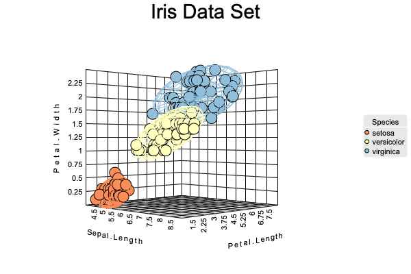

Scatter3D

```r
y <- read.table("https://canvasxpress.org/data/r/cX-irist-dat.txt", header=TRUE, sep="\t",
                quote="", row.names=1, fill=TRUE, check.names=FALSE, stringsAsFactors=FALSE)
z <- read.table("https://canvasxpress.org/data/r/cX-irist-var.txt", header=TRUE, sep= "\t",
                quote="", row.names=1, fill=TRUE, check.names=FALSE, stringsAsFactors=FALSE)

canvasXpress(data      = y,
             varAnnot  = z,
             graphType ="Scatter3D",
             colorBy   = "Species",
             ellipseBy = "Species",
             xAxis     = list("Sepal.Length"),
             yAxis     = list("Petal.Width"),
             zAxis     = list("Petal.Length"),
             theme     = "CanvasXpress",
             title     = "Iris Data Set",
             axisTickScaleFontFactor  = 0.5,
             axisTitleScaleFontFactor = 0.5)
```

### Scatter 2D Matrix Plot

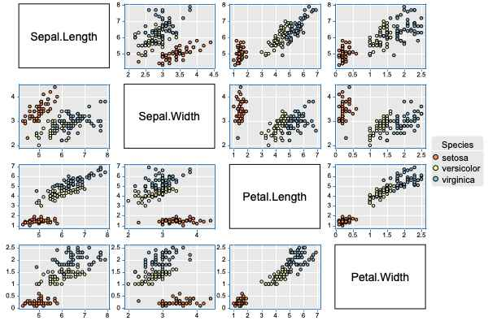

Scatter2DMatrix

```r
y <- read.table("https://canvasxpress.org/data/r/cX-irist-dat.txt", header=TRUE, sep="\t",
                quote="", row.names=1, fill=TRUE, check.names=FALSE, stringsAsFactors=FALSE)
z <- read.table("https://canvasxpress.org/data/r/cX-irist-var.txt", header=TRUE, sep= "\t",
                quote="", row.names=1, fill=TRUE, check.names=FALSE, stringsAsFactors=FALSE)

canvasXpress(data              = y,
             varAnnot          = z,
             graphType         = "Scatter2D",
             colorBy           = "Species",
             layoutAdjust      = TRUE,
             scatterPlotMatrix = TRUE,
             theme             = "CanvasXpress")
```

### Boxplot

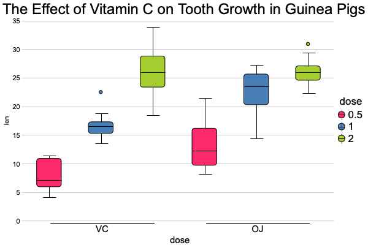

Boxplot

```r
y <- read.table("https://www.canvasxpress.org/data/r/cX-toothgrowth-dat.txt", header=TRUE, sep="\t",
                quote="", row.names=1, fill=TRUE, check.names=FALSE, stringsAsFactors=FALSE)
x <- read.table("https://www.canvasxpress.org/data/r/cX-toothgrowth-smp.txt", header=TRUE, sep="\t",
                quote="", row.names=1, fill=TRUE, check.names=FALSE, stringsAsFactors=FALSE)

canvasXpress(data                  = y,
             smpAnnot              = x,
             graphType             = "Boxplot",
             groupingFactors       = list("dose", "supp"),
             stringSampleFactors   = list("dose"),
             graphOrientation      = "vertical",
             colorBy               = "dose",
             title                 = "The Effect of Vitamin C on Tooth Growth in Guinea Pigs",
             smpTitle              = "dose",
             xAxisTitle            = "len",
             smpLabelRotate        = 90,
             xAxisMinorTicks       = FALSE,
             xAxis2Show            = FALSE,
             legendScaleFontFactor = 1.8)
```

### Heatmap

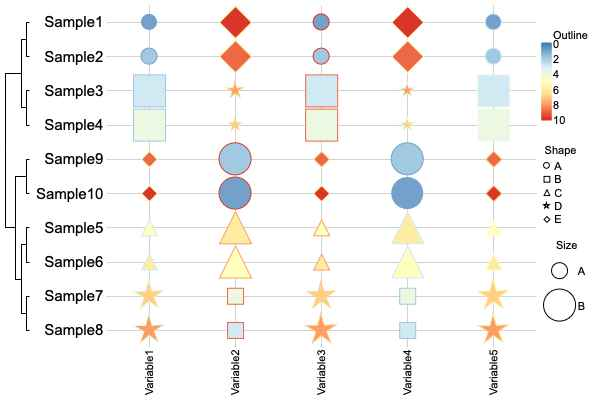

Heatmap

```r
y  <- read.table("https://canvasxpress.org/data/r/cX-multidimensionalheatmap-dat.txt",
                 header=TRUE, sep="\t", quote="", row.names=1, fill=TRUE,
                 check.names=FALSE, stringsAsFactors=FALSE)
y2 <- read.table("https://canvasxpress.org/data/r/cX-multidimensionalheatmap-dat2.txt",
                 header=TRUE, sep="\t", quote="", row.names=1, fill=TRUE,
                    check.names=FALSE, stringsAsFactors=FALSE)
y3 <- read.table("https://canvasxpress.org/data/r/cX-multidimensionalheatmap-dat3.txt",
                 header=TRUE, sep="\t", quote="", row.names=1, fill=TRUE,
                 check.names=FALSE, stringsAsFactors=FALSE)
y4 <- read.table("https://canvasxpress.org/data/r/cX-multidimensionalheatmap-dat4.txt",
                 header=TRUE, sep="\t", quote="", row.names=1, fill=TRUE,
                 check.names=FALSE, stringsAsFactors=FALSE)
x  <- read.table("https://canvasxpress.org/data/r/cX-multidimensionalheatmap-smp.txt",
                 header=TRUE, sep= "\t", quote="", row.names=1, fill=TRUE,
                 check.names=FALSE, stringsAsFactors=FALSE)
z  <- read.table("https://canvasxpress.org/data/r/cX-multidimensionalheatmap-var.txt",
                 header=TRUE, sep= "\t", quote="", row.names=1, fill=TRUE,
                 check.names=FALSE, stringsAsFactors=FALSE)

canvasXpress(data                 = list(y = y, data2 = y2, data3 = y3, data4 = y4),
             smpAnnot             = x,
             varAnnot             = z,
             graphType            = "Heatmap",
             guides               = TRUE,
             outlineBy            = "Outline",
             outlineByData        = "data2",
             shapeBy              = "Shape",
             shapeByData          = "data3",
             sizeBy               = "Size",
             sizeByData           = "data4",
             showHeatmapIndicator = FALSE,
             afterRender          = list(list("clusterSamples")))
```

### Four-way Venn Diagram

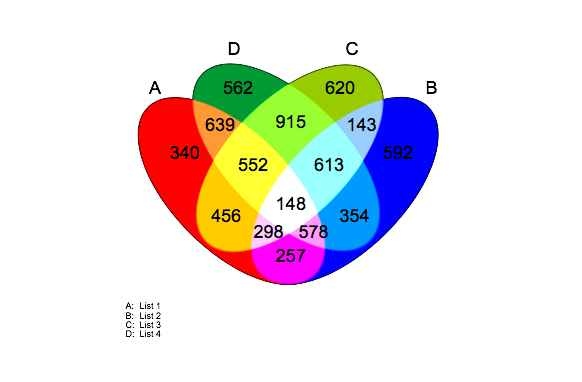

Venn

```r
canvasXpress(vennData   = data.frame(AC=456, A=340, ABC=552, ABCD=148, BC=915,
                                     ACD=298, BCD=613, B=562, CD=143, ABD=578,
                                     C=620, D=592, AB=639, BD=354, AD=257),
             graphType  = "Venn",
             vennLegend = list(A="List 1", D="List 4", C="List 3", B="List 2"),
             vennGroups = 4)
```

## Additional Information

For the use of canvasXpress plots in shiny there are interactive examples available through the package function *cxShinyExample*

```r
#List example names
cxShinyExample()

#Run an interactive shiny example
cxShinyExample(example = "example1")
```

There is also a wealth of additional information including full API documentation and extensive R and JavaScript examples at https://www.canvasxpress.org.